**Atividade 3.2 - Análise de dados: testes de aderência**

1em Escolha duas subamostras geradas na atividade 2.2 (uma com n= 20 e a outra com n=200):

# 1 - Distribuição de frequência para a variável Nota em Matemática para a amostra n=200 e verificação de normalidade

## 1º passo: Histograma

Começarei por fazer um histograma, que além de apresentar as distribuições de frequências da variável, nos fornece um panorama visual acerca de sua semelhança com o formato de uma distribuição normal, se for o caso.

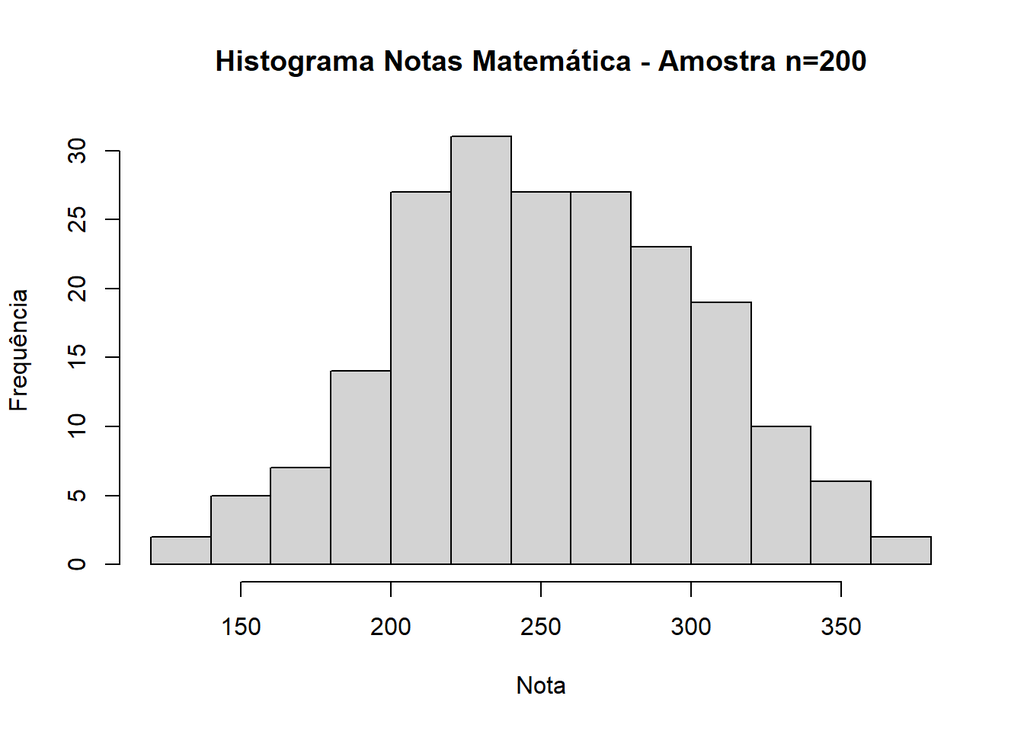

## 2º passo: Gráfico *Quantil-Quantil*

Seguidamente, farei um gráfico Q-Q, que traz mais uma perspectiva visual do esperado para uma distribuição normal (linha cortando o gráfico) com o observado (pontos)

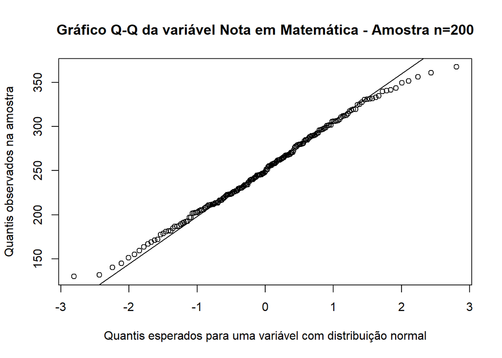

Essas duas abordagens nos ajudam a balizar a decisão. Pela análise visual, a distribuição aparenta ser aproximadamente normal. Porém isso não é suficiente para inferirmos uma resposta. Para tal, é necessário realizar testes de normalidade.

## 3º passo: Realizando testes de normalidade

O teste de *Shapiro-Wilk* apresentou estatística de teste **W=0.9938478**, com **p-valor=0.5782044**. O teste de *Anderson-Darling* apresentou estatística de teste **A=0.2414832**, com **p-valor=0.7691622**. O teste de *Kolmogorov (Lilliefors)* apresentou estatística de teste **D=0.0371028**, com **p-valor=0.7201417**.

Com esses resultados, devemos **aceitar a hipótese de normalidade da amostra**.

# 2 - Testando normalidade das variáveis notas em língua portuguesa e matemática para a amostra (n=20)

De forma análoga à questão anterior, seguirei os 3 passos para testar a normalidade de cada uma das variáveis.

## Variável nota em Matemática

### 1º passo: Histograma

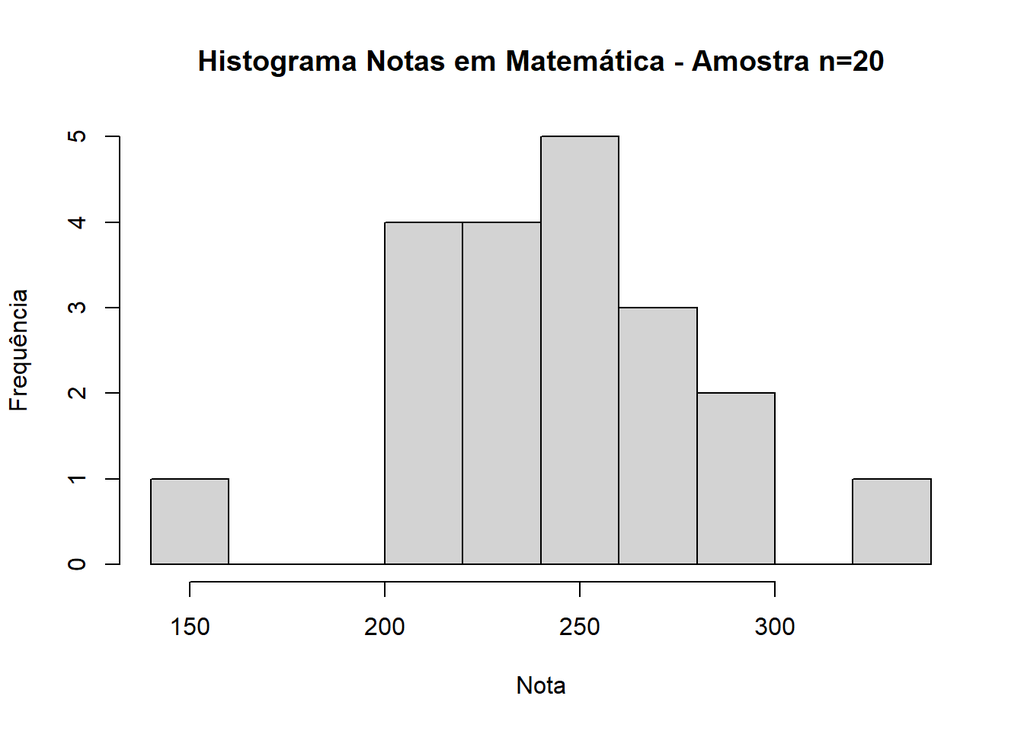

### 2º passo: Gráfico *Quantil-Quantil*

[figure not shown]

### 3º passo: Realizando testes de normalidade

O teste de *Shapiro-Wilk* apresentou estatística de teste **W=0.9861048**, com **p-valor=0.9874872**. O teste de *Anderson-Darling* apresentou estatística de teste **A=0.1640937**, com **p-valor=0.9313657**. O teste de *Kolmogorov (Lilliefors)* apresentou estatística de teste **D=0.0841332**, com **p-valor=0.9696454**.

Com esses resultados, devemos **aceitar a hipótese de normalidade da amostra**.

## Variável Nota em Língua Portuguesa

### 1º passo: Histograma

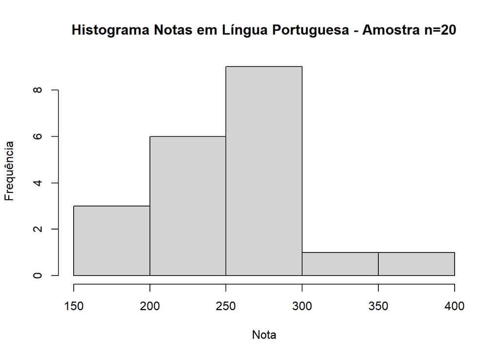

### 2º passo: Gráfico *Quantil-Quantil*

[figure not shown]

### 3º passo: Realizando testes de normalidade

O teste de *Shapiro-Wilk* apresentou estatística de teste **W=0.9732174**, com **p-valor=0.8208311**. O teste de *Anderson-Darling* apresentou estatística de teste **A=0.2572635**, com **p-valor=0.6833147**. O teste de *Kolmogorov (Lilliefors)* apresentou estatística de teste **D=0.1131288**, com **p-valor=0.720879**.

Com esses resultados, devemos **aceitar a hipótese de normalidade da amostra**.

# 3 - Comente os resultados obtidos, à luz da análise descritiva realizada com a amostra com 2000 observações.

Na análise da atividade *1.3*, os resultados obtidos **rejeitaram** a hipótese de normalidade para ambas as variáveis (Nota em Matemática e Nota em Língua Portuguesa) para a amostra n=2000. Nesta atividade (*3.2*) estou trabalhando com duas subamostras (n=20 e n=200), retirados dessa amostra maior. Apesar da amostra original eu ter **rejeitado** a hipótese de normalidade, esta se deu por conta do *p-valor* reduzido, o que é de se esperar em uma amostra grande. Como as amostras aqui trabalhadas são consideravelmente reduzidas, tanto as *estatísticas de teste* quanto os *p-valores* estão na margem de aceitação. Isso se dá por conta dos testes serem conservadores em relação à aceitação da hipótese nula em caso de n pequeno.